# Applied Computational Methods for Social Sciences

Lecture 9: Intro to Geographic Information Systems (GIS)

Bogdan G. Popescu

bogdan.popescu@johncabot.edu

John Cabot University

## What You’ll Learn Today

1. Planet Earth, its shape, and **latitude and longitude**
2. **Coordinate reference systems**: spheres, ellipsoids, geoids, and datums
3. Geographic vs. **projected** coordinate systems
4. **Vector layers**: points, lines, polygons
5. Where to find **country shapefiles** and how to map them in R

By the end, you’ll understand how locations on Earth become data you can map.

## The Earth and the Geographic Coordinates

- The Earth is not a perfect sphere

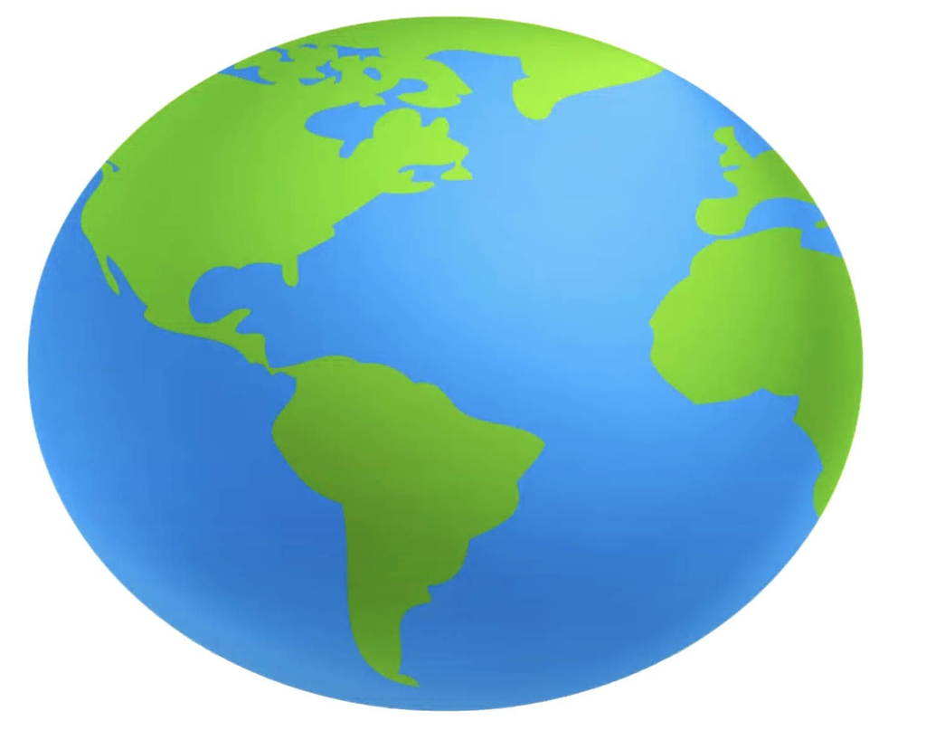

## The Earth and the Geographic Coordinates

- The Earth is not a perfect sphere
- Polar diameter is 12,714 km

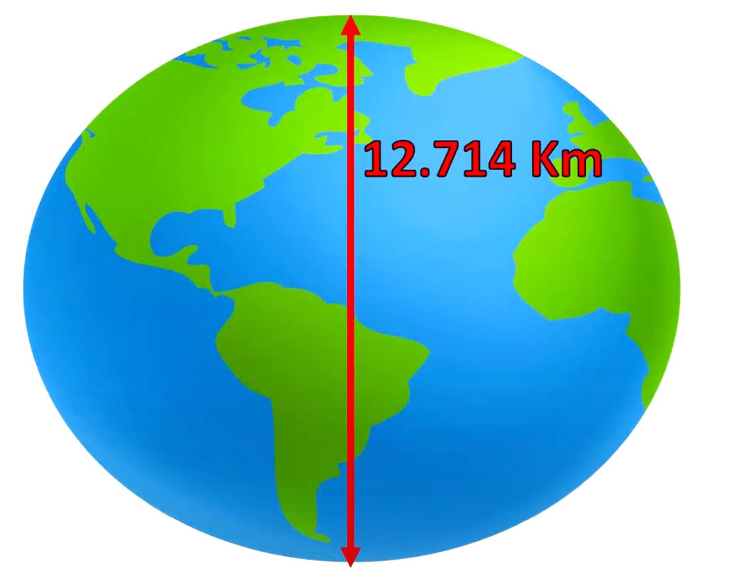

## The Earth and the Geographic Coordinates

- The Earth is not a perfect sphere
- Polar diameter is 12,714 km
- Equatorial diameter is 12,756 km

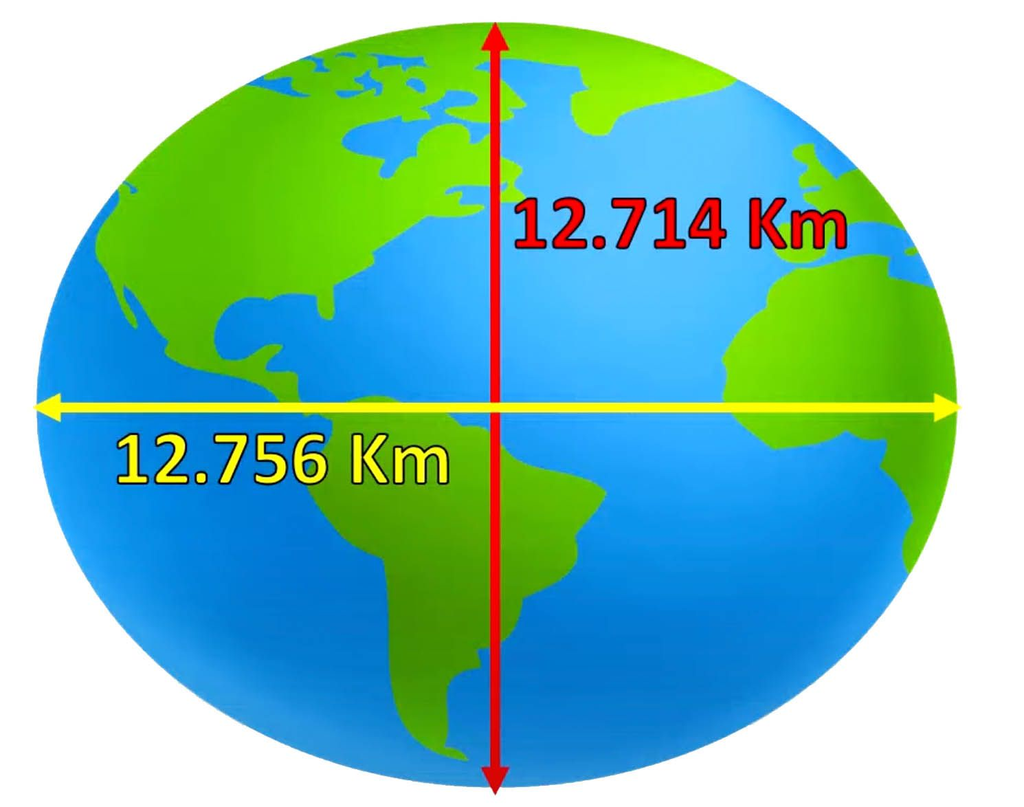

## The Earth and the Geographic Coordinates

- The Earth is not a perfect sphere
- Polar diameter is 12,714 km
- Equatorial diameter is 12,756 km
- The Earth is flattened at the poles and elongated at the equator: **Oblate Spheroid**

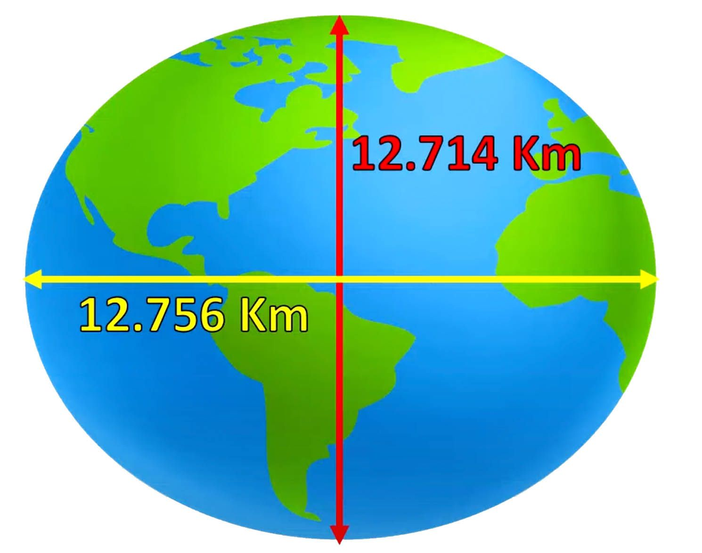

## Cardinal Points

- The main cardinal points are: North, South, East, and West
- These are used for orientation and to express direction on the Earth’s surface

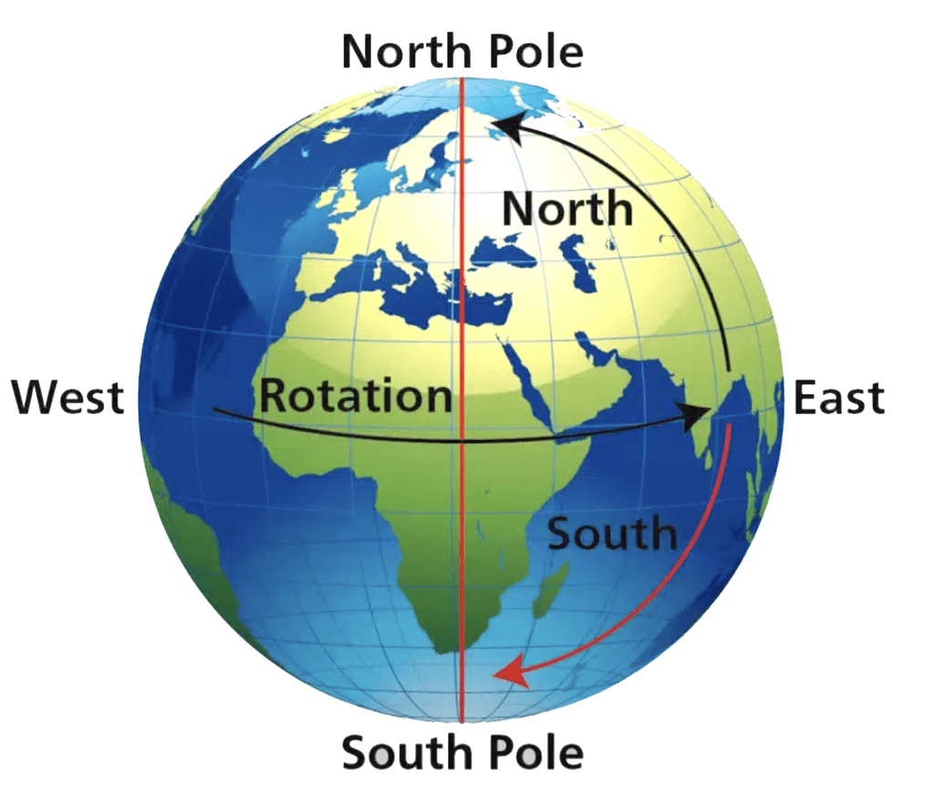

## The Cartesian System

- The Cartesian system is a position reference system

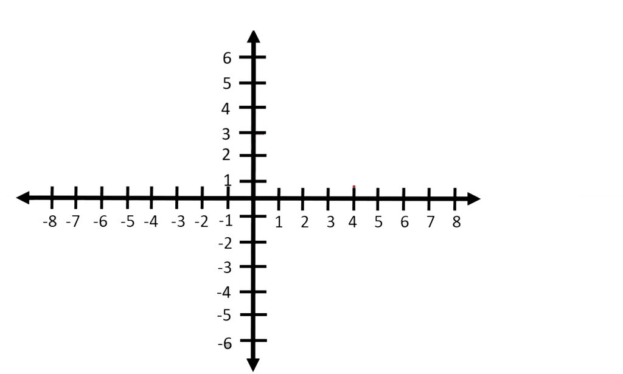

## The Cartesian System

- The Cartesian system is a position reference system
- We can use the two reference axes to express any position through cartesian coordinates

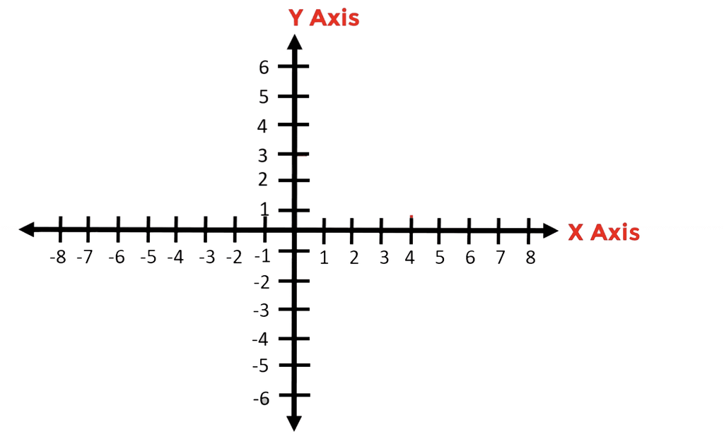

## The Cartesian System

- The Cartesian system is a position reference system
- We can use the two reference axes to express any position through cartesian coordinates
- For example this point is located 4 units on the X axis and 3 units on the Y axis

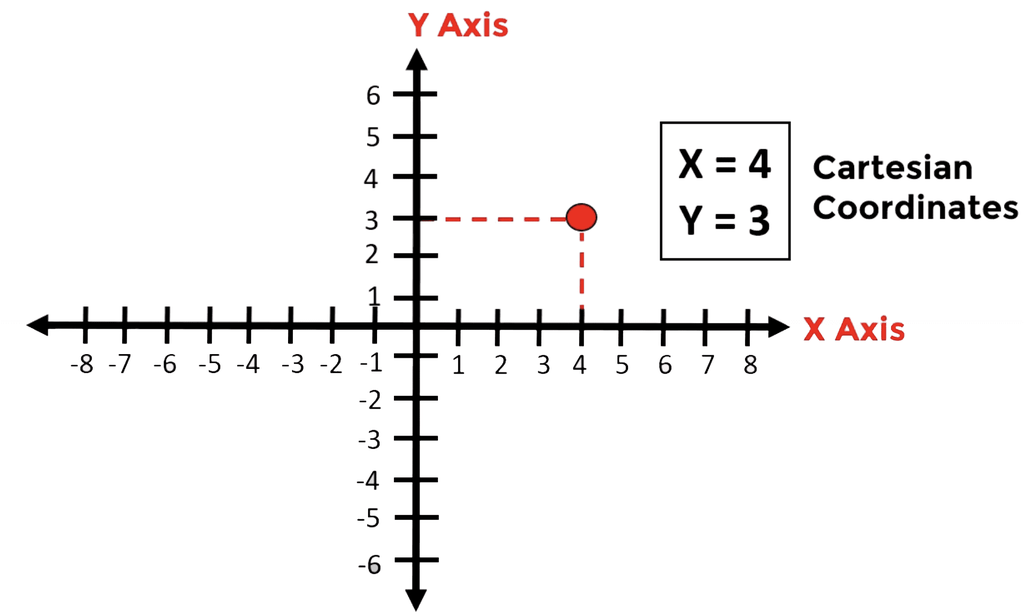

## Position on Earth

The position on Earth can be displayed in a similar way using the **geographic coordinate system**

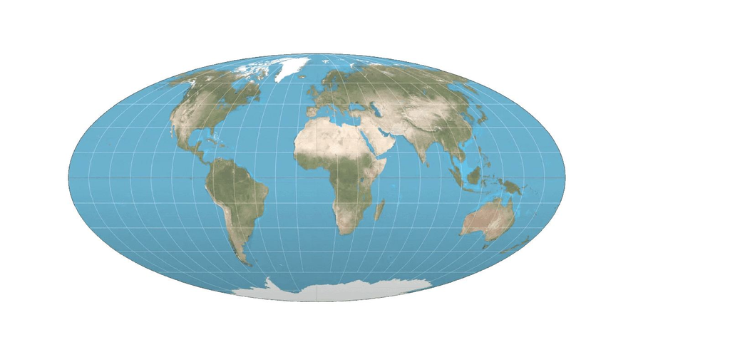

## Position on Earth

Each position on the earth can be identified in terms of latitude and longitude

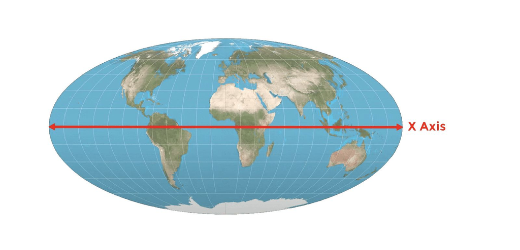

## Position on Earth

Each position on the earth can be identified in terms of latitude and longitude

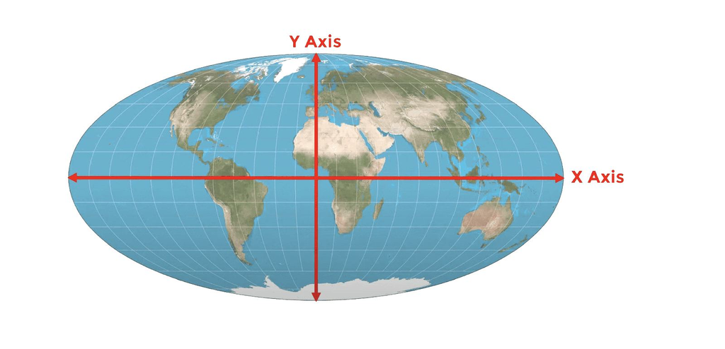

## Position on Earth

Each position on the earth can be identified in terms of latitude and longitude

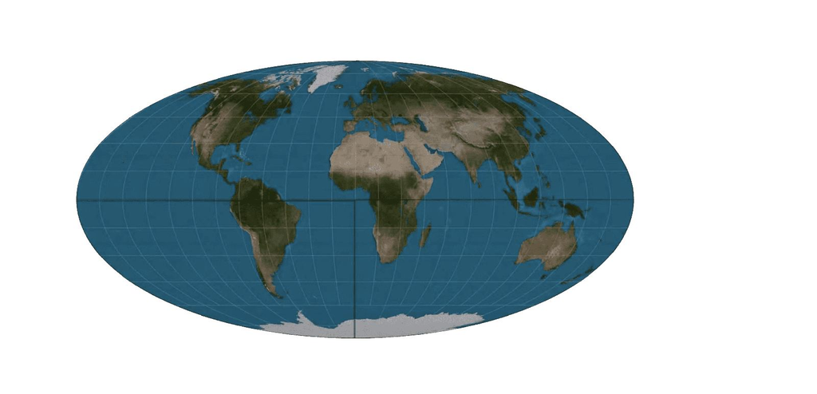

## Position on Earth

Each position on the earth can be identified in terms of latitude and longitude

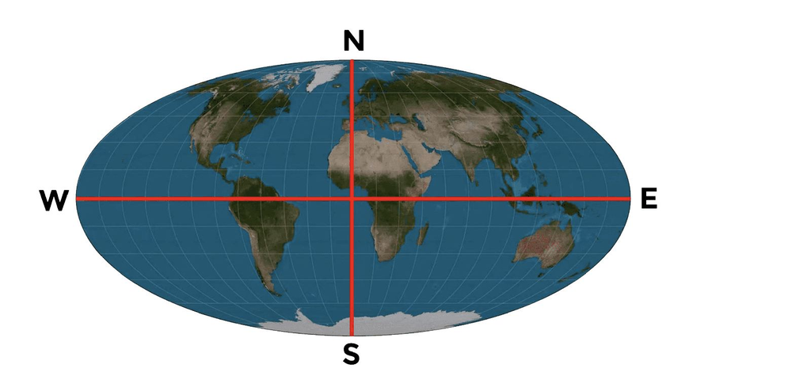

## Position on Earth

Latitude is used to express how far north or how far south a point is

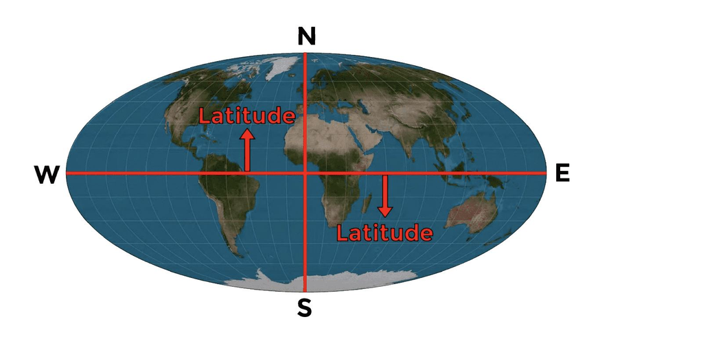

## Position on Earth

Longitude is used to express how far west or how far east a point is

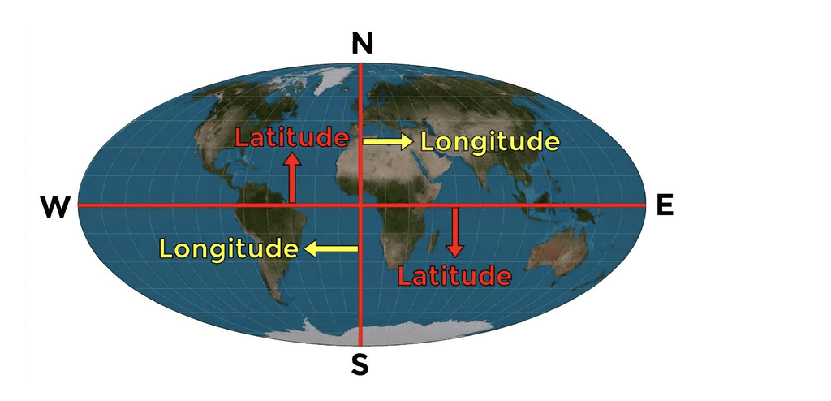

## Position on Earth

As in the Cartesian system, two reference axes are used from which latitude and longitudes are measured

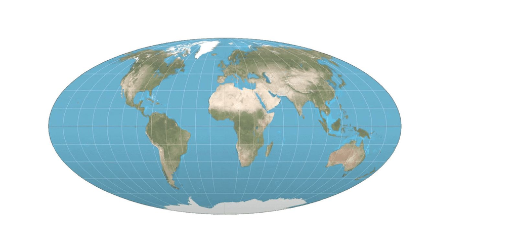

## Position on Earth

As in the Cartesian system, two reference axes are used from which latitude and longitudes are measured

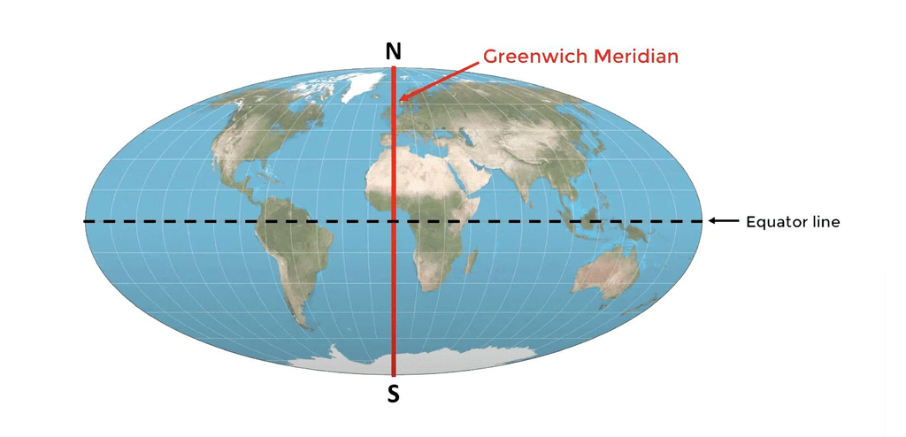

## Position on Earth

These axes divide the earth into four hemispheres

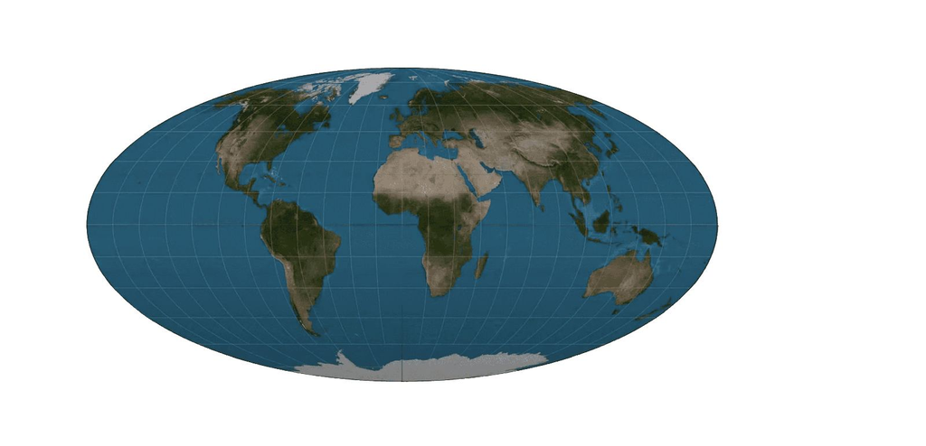

## Position on Earth

These axes divide the earth into four hemispheres

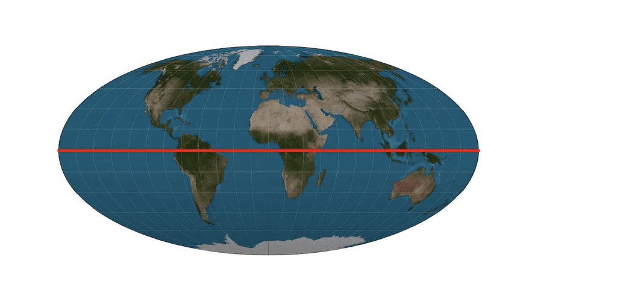

## Position on Earth

These axes divide the earth into four hemispheres

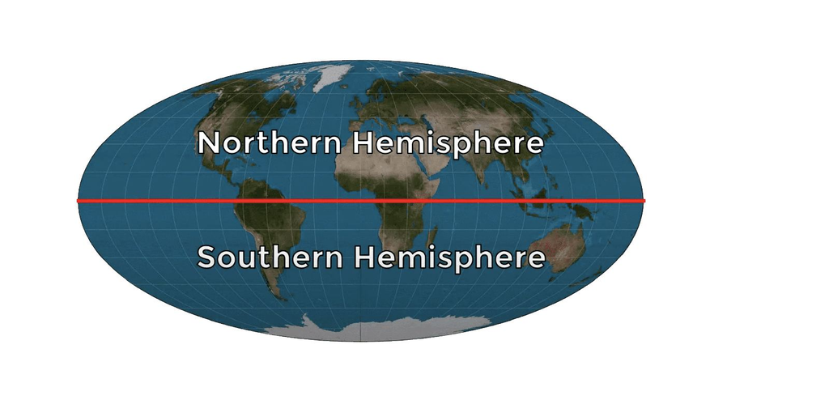

## Position on Earth

These axes divide the earth into four hemispheres

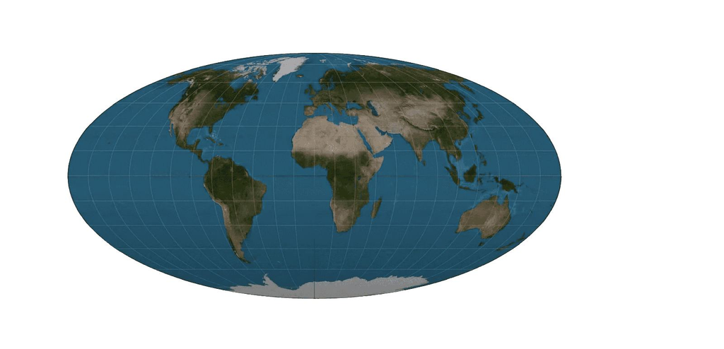

## Position on Earth

These axes divide the earth into four hemispheres

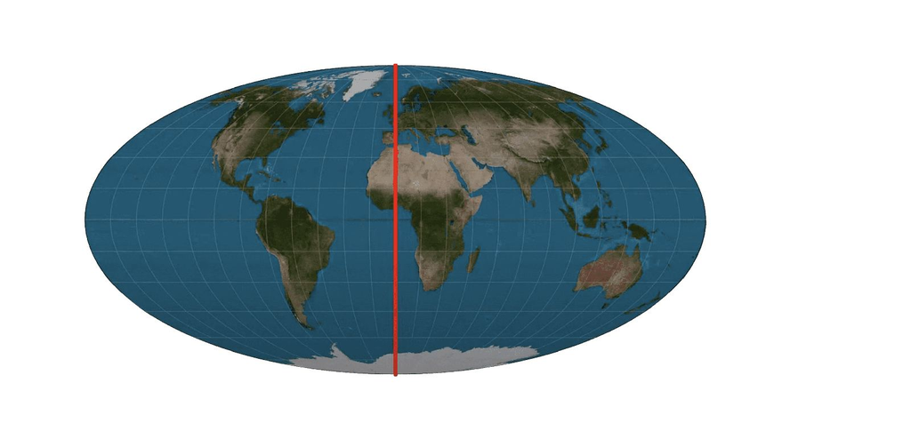

## Position on Earth

These axes divide the earth into four hemispheres

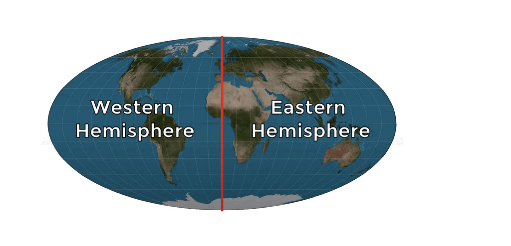

## Latitude and Longitude

Due to the Earth’s size, it is common to use secondary reference lines

- parallels
- meridians

## Meridians

- **Meridians** are semi-circles that join the North and South Poles
- They are measured in degrees in relation to the prime meridian (Greenwich meridian)
- These lines are used as reference for the longitude

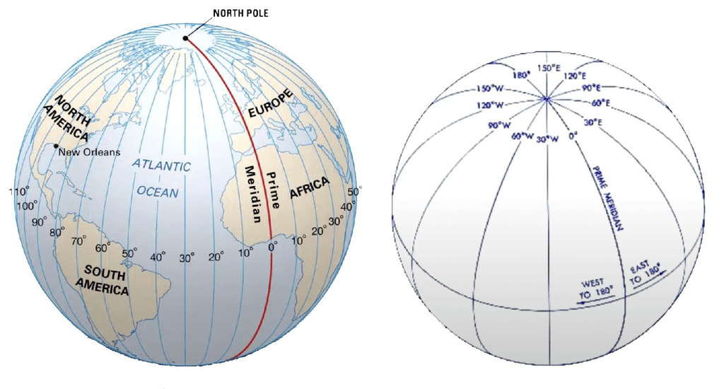

## Parallels

- **Parallels** are circles that are parallel to the Equator line
- They are measured in degrees in relation to the Equator line
- These lines are used as reference for the latitudes

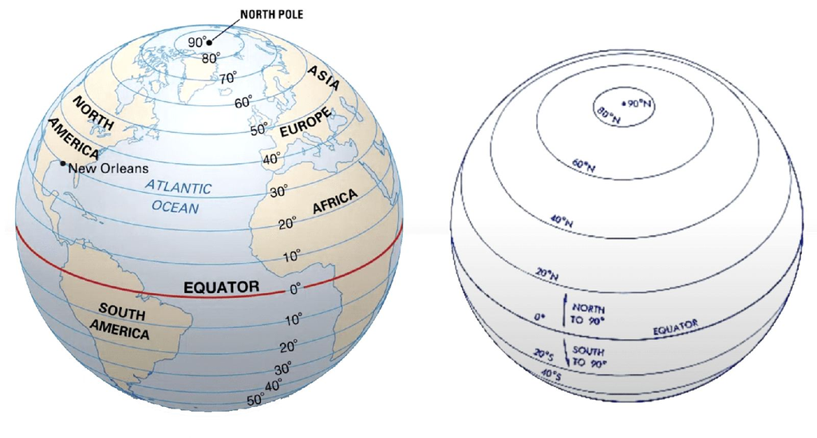

## Geographic Graticule

- The resulting grid from parallels and meridians is called the geographic graticule (grid)

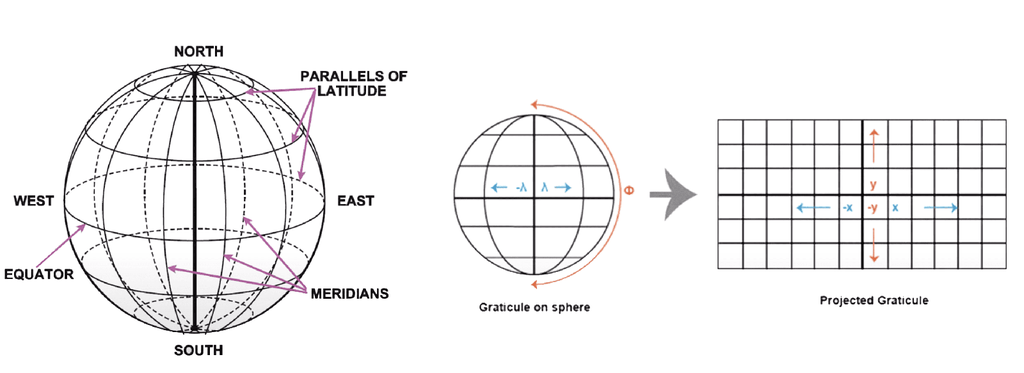

## Latitude

The latitude is the angular distance between the Equator and a point on the Earth’s surface, measured in degrees, minutes, and seconds of an arc

What is an arc?

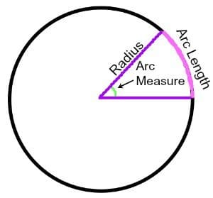

The latitude measures how far north or how far south a point is

## Latitude

- Latitude is 0 degrees at the equator line
- It then increases gradually until 90 degrees at each of the poles

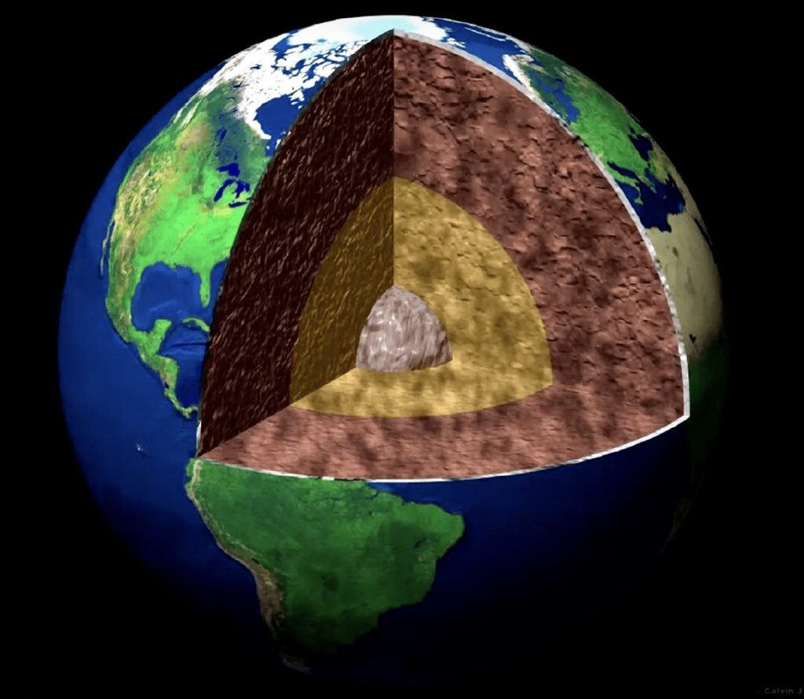

## Latitude

- Latitude is 0 degrees at the equator line
- It then increases gradually until 90 degrees at each of the poles

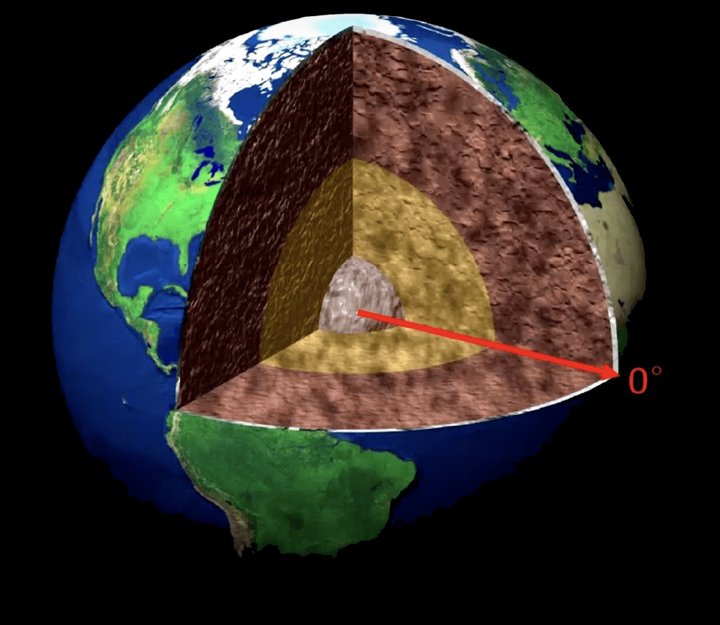

## Latitude

- Latitude is 0 degrees at the equator line
- It then increases gradually until 90 degrees at each of the poles

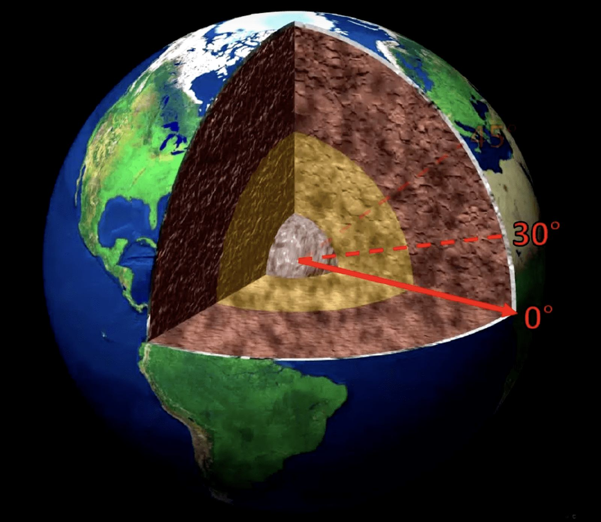

## Latitude

- Latitude is 0 degrees at the equator line
- It then increases gradually until 90 degrees at each of the poles

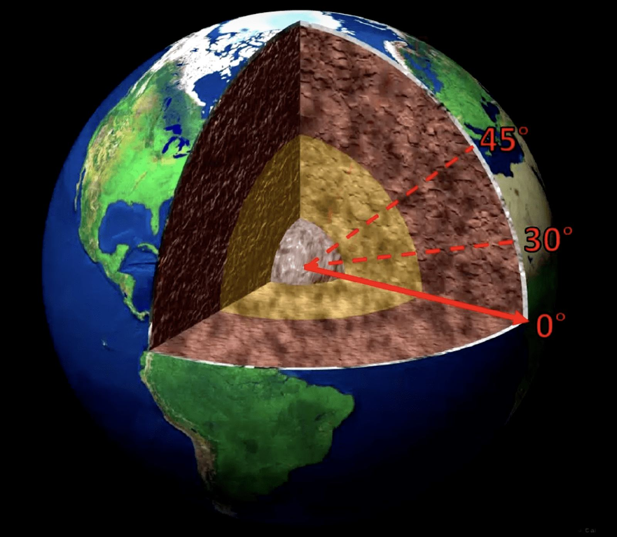